# Multiomics integration of colorectal cancer - TCGA-COAD

# 1. Introduction

## What is multiomics ?

Biology does not happen at a single molecular level. A tumor cell is simultaneously shaped by its epigenome, its transcriptome, and its proteome. Each layer captures a different aspect of cellular state - and none of them alone tells the full story.

**Multiomics integration** aims to find shared molecular patterns across these layers simultaneously. In cancer, this approach is particularly powerful because tumor heterogeneity is driven by alterations at multiple levels at once.

## What is MOFA+ ?

**MOFA+** (Multi-Omics Factor Analysis, version 2) is an unsupervised statistical framework that learns a set of **latent factors** from multiple omics datasets simultaneously. Each factor represents a compressed biological signal shared - to varying degrees - across modalities.

```
RNA-seq (3000 genes)       \
                            --> MOFA+ --> 15 latent factors
Methylation (3000 CpG)     /
```

Each factor has two components :

- **Scores** : one value per patient - how strongly each patient expresses that factor
- **Weights** : one value per feature - how much each gene or CpG contributes to that factor

## Biological question

> Which shared molecular patterns between DNA methylation and gene expression distinguish early-stage colorectal tumors (stage I-II) from advanced tumors (stage III-IV) in the TCGA-COAD cohort ?

# 2. Setup

## Libraries

```r
library(curatedTCGAData)
library(MultiAssayExperiment)
library(TCGAutils)
library(DESeq2)
library(minfi)
library(matrixStats)
library(MOFA2)
library(survival)
library(survminer)
library(ggplot2)
library(gridExtra)
library(IlluminaHumanMethylation450kanno.ilmn12.hg19)
library(gprofiler2)
library(tidyverse)

set.seed(42)
```

# 3. Data

## Download

We use `curatedTCGAData` to access TCGA-COAD data directly from Bioconductor. This package provides pre-processed, compressed data ready for analysis - avoiding the need to download large raw files from the GDC portal.

```r
coad <- curatedTCGAData(
  diseaseCode = "COAD",
  assays      = c("RNASeq2GeneNorm_illuminahiseq", "Methylation_methyl450"),
  dry.run     = FALSE,
  version     = "2.0.1"
)
```

```r
coad
```

```
## A MultiAssayExperiment object of 2 listed
##  experiments with user-defined names and respective classes.
##  Containing an ExperimentList class object of length 2:
##  [1] COAD_RNASeq2GeneNorm_illuminahiseq-20160128: SummarizedExperiment with 20501 rows and 326 columns
##  [2] COAD_Methylation_methyl450-20160128: SummarizedExperiment with 485577 rows and 333 columns
## Functionality:
##  experiments() - obtain the ExperimentList instance
##  colData() - the primary/phenotype DataFrame
##  sampleMap() - the sample coordination DataFrame
##  `$`, `[`, `[[` - extract colData columns, subset, or experiment
##  *Format() - convert into a long or wide DataFrame
##  assays() - convert ExperimentList to a SimpleList of matrices
##  exportClass() - save data to flat files
```

## Clinical data

We initially considered MSI (microsatellite instability) status as our primary clinical variable. However, it was available for only 90 out of 313 patients - insufficient for robust analysis. We therefore chose **overall survival** as the primary endpoint, and **tumor stage** (early vs advanced) as the secondary validation variable.

```r
clinical_raw <- as.data.frame(colData(coad))

clinical_surv <- clinical_raw %>%
  dplyr::mutate(
    patient_id = substr(rownames(clinical_raw), 1, 12),
    status = dplyr::case_when(
      vital_status.x == "1" ~ 1,
      vital_status.x == "0" ~ 0,
      TRUE                  ~ NA_real_
    ),
    time_days = dplyr::case_when(
      status == 1 ~ as.numeric(days_to_death.x),
      status == 0 ~ as.numeric(days_to_last_followup.x),
      TRUE        ~ NA_real_
    ),
    stage_bin = dplyr::case_when(
      pathologic_stage %in%
        c("stage i", "stage ia", "stage ii",
          "stage iia", "stage iib", "stage iic")   ~ "early",
      pathologic_stage %in%
        c("stage iii", "stage iiia", "stage iiib",
          "stage iiic", "stage iv", "stage iva",
          "stage ivb")                              ~ "advanced",
      TRUE ~ NA_character_
    )
  ) %>%
  dplyr::select(patient_id, status, time_days, stage_bin) %>%
  dplyr::filter(!is.na(status), !is.na(time_days), time_days > 0)

cat("Patients with complete survival data :", nrow(clinical_surv), "\n")
```

```
## Patients with complete survival data : 308
```

```r
cat("Vital status :\n")
```

```
## Vital status :
```

```r
print(table(clinical_surv$status))
```

```
##
##   0   1
## 234  74
```

```r
cat("Tumor stage :\n")
```

```
## Tumor stage :
```

```r
print(table(clinical_surv$stage_bin, useNA = "always"))
```

```
##
## advanced    early     <NA>
##      131      168        9
```

```r
cat("Median follow-up :", round(median(clinical_surv$time_days) / 365, 1), "years\n")
```

```
## Median follow-up : 1.9 years
```

## Omics matrices and preprocessing

```r
rna_mat  <- assay(coad[["COAD_RNASeq2GeneNorm_illuminahiseq-20160128"]])
meth_mat <- assay(coad[["COAD_Methylation_methyl450-20160128"]])

cat("RNA-seq raw :", nrow(rna_mat),  "genes x", ncol(rna_mat),  "samples\n")
```

```
## RNA-seq raw : 20501 genes x 326 samples
```

```r
cat("Methylation :", nrow(meth_mat), "CpG x",   ncol(meth_mat), "samples\n")
```

```
## Methylation : 485577 CpG x 333 samples
```

### Primary tumor selection

TCGA samples include primary tumors, normal tissue, recurrent tumors, and metastases. We keep only primary solid tumors (tissue code `01`) to ensure biological homogeneity.

```r
keep_primary_tumor <- function(mat) {
  tissue_code      <- substr(colnames(mat), 14, 15)
  mat_01           <- mat[, tissue_code == "01", drop = FALSE]
  colnames(mat_01) <- substr(colnames(mat_01), 1, 12)
  mat_01           <- mat_01[, !duplicated(colnames(mat_01)), drop = FALSE]
  return(mat_01)
}

rna_tumor  <- keep_primary_tumor(rna_mat)
meth_tumor <- keep_primary_tumor(meth_mat)

cat("RNA  primary tumors :", ncol(rna_tumor),  "patients\n")
```

```
## RNA  primary tumors : 283 patients
```

```r
cat("Meth primary tumors :", ncol(meth_tumor), "patients\n")
```

```
## Meth primary tumors : 293 patients
```

### Patient alignment and dimension reduction

```r
overlap_final <- Reduce(intersect, list(
  colnames(rna_tumor),
  colnames(meth_tumor),
  clinical_surv$patient_id
))
cat("Final overlap :", length(overlap_final), "patients\n")
```

```
## Final overlap : 271 patients
```

```r
rna_final  <- rna_tumor[,  overlap_final]
meth_final <- meth_tumor[, overlap_final]
clin_final <- clinical_surv[match(overlap_final, clinical_surv$patient_id), ]

cat("Same order RNA / Methylation :",
    all(colnames(rna_final) == colnames(meth_final)), "\n")
```

```
## Same order RNA / Methylation : TRUE
```

```r
cat("Same order RNA / Clinical    :",
    all(colnames(rna_final) == clin_final$patient_id), "\n")
```

```
## Same order RNA / Clinical    : TRUE
```

We retain the **3000 most variable features** per modality. Variable features carry the biological signal; stable features are mostly noise.

```r
# RNA-seq : top 3000 most variable genes
vars_rna <- rowVars(rna_final)
rna_top  <- rna_final[order(vars_rna, decreasing = TRUE)[1:3000], ]

# Methylation : remove CpG with > 20% missing values, then top 3000
na_frac    <- rowMeans(is.na(meth_final))
meth_clean <- meth_final[na_frac < 0.2, ]
vars_meth  <- rowVars(meth_clean, na.rm = TRUE)
meth_top   <- meth_clean[order(vars_meth, decreasing = TRUE)[1:3000], ]

cat("RNA reduced :", nrow(rna_top), "genes x", ncol(rna_top), "patients\n")
```

```
## RNA reduced : 3000 genes x 271 patients
```

```r
cat("Meth reduced :", nrow(meth_top), "CpG x", ncol(meth_top), "patients\n")
```

```
## Meth reduced : 3000 CpG x 271 patients
```

# 4. MOFA+ model

## Training

```r
mofa_data <- list(
  RNA         = as.matrix(rna_top),
  Methylation = as.matrix(meth_top)
)

mofa <- create_mofa(mofa_data)

model_opts             <- get_default_model_options(mofa)
model_opts$num_factors <- 15

train_opts                  <- get_default_training_options(mofa)
train_opts$convergence_mode <- "slow"
train_opts$seed             <- 42

mofa <- prepare_mofa(
  mofa,
  data_options     = get_default_data_options(mofa),
  model_options    = model_opts,
  training_options = train_opts
)

mofa <- run_mofa(mofa, use_basilisk = TRUE)
saveRDS(mofa, "data/processed/mofa_model.rds")
```

```r
mofa
```

```
## Trained MOFA with the following characteristics:
##  Number of views: 2
##  Views names: RNA Methylation
##  Number of features (per view): 3000 3000
##  Number of groups: 1
##  Groups names: group1
##  Number of samples (per group): 271
##  Number of factors: 15
```

## Variance explained

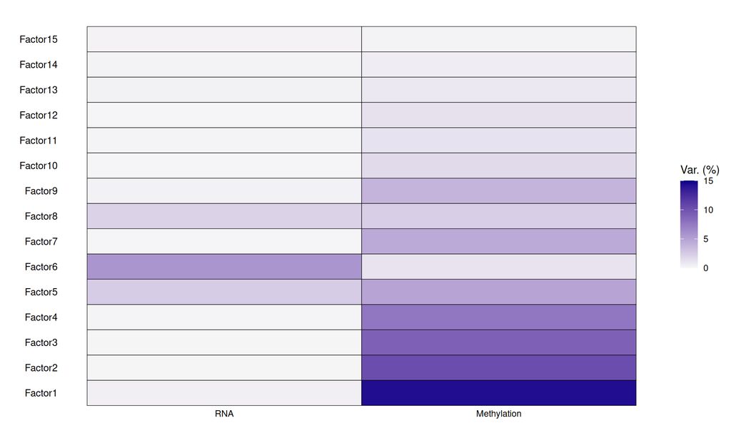

Variance explained by each factor per modality. Darker color = stronger signal.

```r
plot_variance_explained(mofa, max_r2 = 15)
```

**Reading the heatmap :**

[figure not shown]

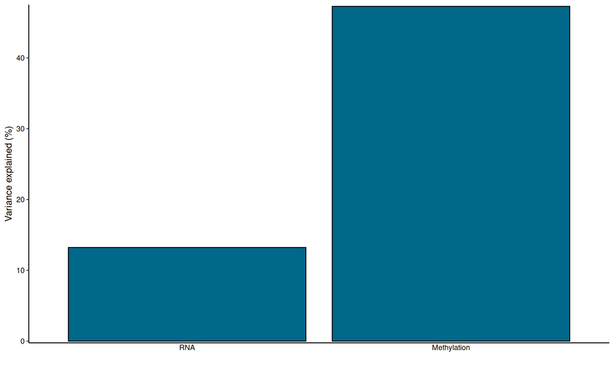

Total variance explained per modality across all 15 factors.

```r
plot_variance_explained(mofa, plot_total = TRUE)
```

- **Methylation** : ~47% - highly structured, consistent with the known epigenetic heterogeneity of colorectal cancer
- **RNA-seq** : ~13% - expected for transcriptomics, which is noisier

# 5. Clinical validation

## Factor scores extraction

```r
factors_raw           <- get_factors(mofa, factors = "all")[[1]]
factors_df            <- as.data.frame(factors_raw)
factors_df$patient_id <- rownames(factors_df)

clin_mofa <- clin_final %>%
  dplyr::inner_join(factors_df, by = "patient_id")

cat("Patients in analysis :", nrow(clin_mofa), "\n")
```

```
## Patients in analysis : 271
```

## Overall survival - Cox regression

We test whether each factor predicts overall survival using univariate Cox regression.

```r
results_cox <- data.frame()

for (f in paste0("Factor", 1:15)) {
  formula <- as.formula(paste("Surv(time_days, status) ~", f))
  cox_fit  <- coxph(formula, data = clin_mofa)
  cox_sum  <- summary(cox_fit)
  results_cox <- rbind(results_cox, data.frame(
    Factor  = f,
    HR      = round(cox_sum$coefficients[, "exp(coef)"], 3),
    p_value = round(cox_sum$coefficients[, "Pr(>|z|)"],  4)
  ))
}

results_cox <- results_cox[order(results_cox$p_value), ]
knitr::kable(results_cox, caption = "Univariate Cox regression results - all 15 factors")
```

Univariate Cox regression results - all 15 factors

|  | Factor | HR | p_value |
| --- | --- | --- | --- |
| 4 | Factor4 | 0.924 | 0.0648 |
| 10 | Factor10 | 1.088 | 0.1161 |
| 13 | Factor13 | 1.098 | 0.1341 |
| 8 | Factor8 | 0.949 | 0.1880 |
| 14 | Factor14 | 1.056 | 0.2836 |
| 6 | Factor6 | 1.021 | 0.3829 |
| 11 | Factor11 | 1.043 | 0.4272 |
| 7 | Factor7 | 1.040 | 0.4840 |
| 9 | Factor9 | 0.968 | 0.4987 |
| 2 | Factor2 | 1.025 | 0.5120 |
| 15 | Factor15 | 0.965 | 0.5572 |
| 1 | Factor1 | 0.982 | 0.6871 |
| 5 | Factor5 | 0.984 | 0.7165 |
| 12 | Factor12 | 0.993 | 0.9115 |
| 3 | Factor3 | 1.005 | 0.9173 |

## Tumor stage - Wilcoxon test

**Biological question :** Which MOFA+ factors distinguish early (stage I-II) from advanced (stage III-IV) tumors ?

```r
clin_stage <- clin_mofa %>%
  dplyr::filter(!is.na(stage_bin))

cat("Patients with known stage :", nrow(clin_stage), "\n")
```

```
## Patients with known stage : 262
```

```r
print(table(clin_stage$stage_bin))
```

```
##
## advanced    early
##      115      147
```

```r
results_stage <- data.frame()

for (f in paste0("Factor", 1:15)) {
  test  <- wilcox.test(clin_stage[[f]] ~ clin_stage$stage_bin)
  means <- tapply(clin_stage[[f]], clin_stage$stage_bin, mean)
  results_stage <- rbind(results_stage, data.frame(
    Factor        = f,
    mean_early    = round(means["early"],    3),
    mean_advanced = round(means["advanced"], 3),
    p_value       = round(test$p.value,      4)
  ))
}

results_stage <- results_stage[order(results_stage$p_value), ]
knitr::kable(results_stage,
             caption = "Wilcoxon test - factor scores by tumor stage")
```

Wilcoxon test - factor scores by tumor stage

|  | Factor | mean_early | mean_advanced | p_value |
| --- | --- | --- | --- | --- |
| early4 | Factor5 | 0.516 | -0.510 | 0.0030 |
| early13 | Factor14 | -0.299 | 0.406 | 0.0067 |
| early2 | Factor3 | -0.406 | 0.445 | 0.0158 |
| early8 | Factor9 | -0.250 | 0.330 | 0.0301 |
| early11 | Factor12 | 0.272 | -0.264 | 0.0306 |
| early5 | Factor6 | -0.434 | 0.611 | 0.0320 |
| early9 | Factor10 | -0.275 | 0.311 | 0.0470 |
| early12 | Factor13 | 0.253 | -0.319 | 0.0606 |
| early | Factor1 | 0.374 | -0.414 | 0.0620 |
| early1 | Factor2 | 0.341 | -0.334 | 0.1257 |
| early10 | Factor11 | -0.174 | 0.222 | 0.1483 |
| early7 | Factor8 | 0.070 | -0.080 | 0.2812 |
| early3 | Factor4 | 0.077 | -0.201 | 0.3610 |
| early14 | Factor15 | 0.016 | 0.127 | 0.4758 |
| early6 | Factor7 | 0.045 | -0.128 | 0.5206 |

**7 factors reach p < 0.05 :**

- **Higher in advanced tumors** : Factor14, Factor3, Factor9, Factor6, Factor10 - increase with progression
- **Higher in early tumors** : Factor5 (p = 0.003, most significant), Factor12 - decrease with progression

## Visualization

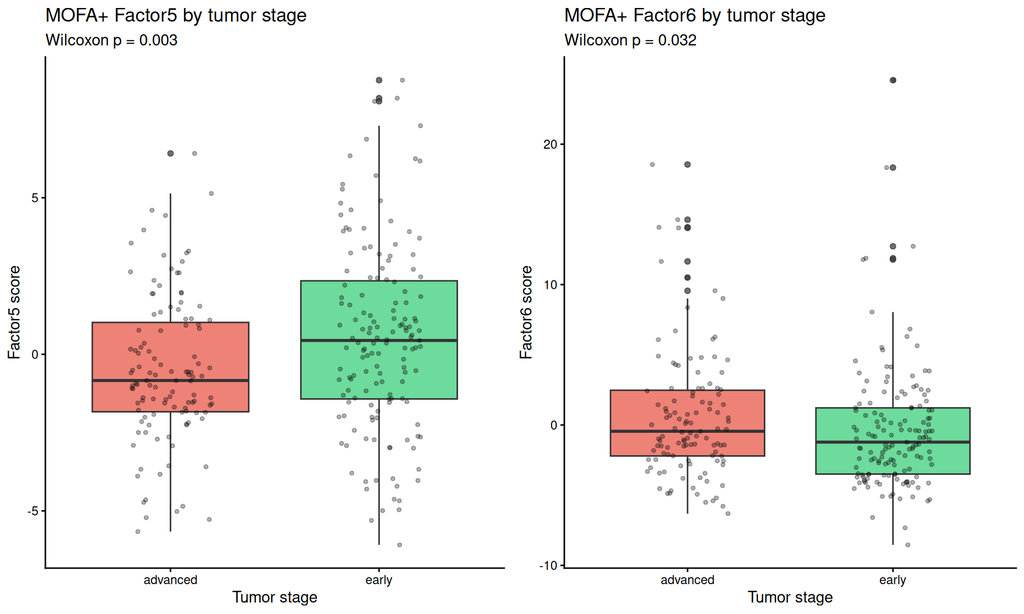

MOFA+ Factor5 and Factor6 scores by tumor stage. Green = early (stage I-II), red = advanced (stage III-IV).

```r
p1 <- ggplot(clin_stage, aes(x = stage_bin, y = Factor5,
                              fill = stage_bin)) +
  geom_boxplot(alpha = 0.7) +
  geom_jitter(width = 0.2, alpha = 0.3, size = 1) +
  scale_fill_manual(values = c("early" = "#2ECC71", "advanced" = "#E74C3C")) +
  labs(title = "MOFA+ Factor5 by tumor stage",
       subtitle = "Wilcoxon p = 0.003",
       x = "Tumor stage", y = "Factor5 score") +
  theme_classic() +
  theme(legend.position = "none")

p2 <- ggplot(clin_stage, aes(x = stage_bin, y = Factor6,
                              fill = stage_bin)) +
  geom_boxplot(alpha = 0.7) +
  geom_jitter(width = 0.2, alpha = 0.3, size = 1) +
  scale_fill_manual(values = c("early" = "#2ECC71", "advanced" = "#E74C3C")) +
  labs(title = "MOFA+ Factor6 by tumor stage",
       subtitle = "Wilcoxon p = 0.032",
       x = "Tumor stage", y = "Factor6 score") +
  theme_classic() +
  theme(legend.position = "none")

grid.arrange(p1, p2, ncol = 2)
```

# 6. Biological interpretation - Factor5

## RNA-seq weights

```r
weights_rna <- get_weights(mofa, views = "RNA", factors = "Factor5")[[1]]

top_rna_pos <- head(sort(weights_rna[, 1], decreasing = TRUE),  20)
top_rna_neg <- head(sort(weights_rna[, 1], decreasing = FALSE), 20)

cat("Top 20 genes HIGH in early tumors (positive weights):\n")
```

```
## Top 20 genes HIGH in early tumors (positive weights):
```

```r
print(top_rna_pos)
```

```
##    RPS14    RPL41     RPS9     RPS8    RPL7A    RPLP0    RPS11    RPL18
## 1470.512 1462.975 1380.104 1371.024 1359.449 1334.840 1331.458 1261.421
##   TMSB10    RPS16    RPL32   RPL13A    RPL27    RPLP1    RPL12    RPL35
## 1227.712 1214.957 1209.269 1188.618 1173.854 1169.290 1152.411 1148.001
##     RPL5    RPS12    RPL26   RPL10A
## 1128.382 1114.828 1101.148 1100.913
```

```r
cat("\nTop 20 genes HIGH in advanced tumors (negative weights):\n")
```

```
##
## Top 20 genes HIGH in advanced tumors (negative weights):
```

```r
print(top_rna_neg)
```

```
## LOC647979      PYGB     SRRM2      CDH1      MYH9     YWHAB     ATP9A   SLC26A3
## -781.6838 -719.2670 -658.7216 -637.8104 -635.7717 -593.4929 -551.6965 -537.3071
##      CTSA     HNF4A      PLEC      GNAS     NUMA1     PRKDC    POFUT1     MYH14
## -510.3494 -479.2473 -478.1152 -466.0550 -450.7526 -449.2549 -432.3279 -427.7365
##    TGOLN2      LRP1    SPTBN1     RNF43
## -414.6868 -414.3599 -413.7355 -397.2881
```

**Early tumors** are dominated by ribosomal protein genes (RPL/RPS family) - a signature of active and coordinated translation machinery, characteristic of well-differentiated functional cells.

**Advanced tumors** show overexpression of MYH9/MYH14 (cell motility), PRKDC (DNA repair and genomic instability), RNF43 (Wnt pathway deregulation), and HNF4A (loss of intestinal differentiation) - a dedifferentiation and invasion signature.

## DNA methylation weights and annotation

```r
weights_meth <- get_weights(mofa, views = "Methylation", factors = "Factor5")[[1]]

top_meth_pos <- head(sort(weights_meth[, 1], decreasing = TRUE),  20)
top_meth_neg <- head(sort(weights_meth[, 1], decreasing = FALSE), 20)
```

```r
anno_450k <- getAnnotation(IlluminaHumanMethylation450kanno.ilmn12.hg19)
cols_keep <- c("UCSC_RefGene_Name", "Relation_to_Island", "UCSC_RefGene_Group")

anno_pos <- as.data.frame(anno_450k[names(top_meth_pos), cols_keep])
anno_neg <- as.data.frame(anno_450k[names(top_meth_neg), cols_keep])

cat("CpG hypermethylated in EARLY tumors :\n")
```

```
## CpG hypermethylated in EARLY tumors :
```

```r
knitr::kable(anno_pos,
             caption = "CpG probes with highest positive weights in Factor5 (early tumors)")
```

CpG probes with highest positive weights in Factor5 (early tumors)

|  | UCSC_RefGene_Name | Relation_to_Island | UCSC_RefGene_Group |
| --- | --- | --- | --- |
| cg11051055 | XKR6 | Island | 1stExon |
| cg15301489 | XKR6 | Island | 1stExon |
| cg14530233 | XKR6 | Island | TSS1500 |
| cg27487839 | XKR6 | Island | 1stExon |
| cg21653184 | ZSCAN18;ZSCAN18;ZSCAN18;ZSCAN18;ZSCAN18 | Island | Body;5’UTR;1stExon;5’UTR;5’UTR |
| cg26675876 | XKR6 | Island | TSS1500 |
| cg11156672 | MYH10 | Island | 5’UTR |
| cg10747118 |  | S_Shore |  |
| cg15305070 |  | OpenSea |  |
| cg18428688 | ZSCAN18;ZSCAN18;ZSCAN18;ZSCAN18 | Island | Body;TSS200;TSS200;TSS200 |
| cg27260867 |  | N_Shore |  |
| cg13485335 | POU2F3 | OpenSea | Body |
| cg07195011 | CTNND2 | Island | TSS200 |
| cg20927547 |  | OpenSea |  |
| cg01072076 |  | Island |  |
| cg24820672 |  | N_Shore |  |
| cg08630279 | ZNF569 | Island | TSS200 |
| cg15627089 |  | N_Shore |  |
| cg18209212 | FZD10 | Island | TSS1500 |
| cg19396867 |  | N_Shore |  |

Key genes : **XKR6** (apoptosis regulator, 5 probes at TSS/1stExon), **FZD10** (Wnt receptor), **ZSCAN18** (transcription factor)

```r
cat("CpG hypermethylated in ADVANCED tumors :\n")
```

```
## CpG hypermethylated in ADVANCED tumors :
```

```r
knitr::kable(anno_neg,
             caption = "CpG probes with highest negative weights in Factor5 (advanced tumors)")
```

CpG probes with highest negative weights in Factor5 (advanced tumors)

|  | UCSC_RefGene_Name | Relation_to_Island | UCSC_RefGene_Group |
| --- | --- | --- | --- |
| cg12019614 | DOCK6 | Island | Body |
| cg00902147 | CANT1;CANT1;CANT1 | Island | Body;Body;Body |
| cg14255824 | TJP2;TJP2;TJP2;TJP2 | OpenSea | Body;5’UTR;Body;Body |
| cg26668151 | DNAJB6 | OpenSea | Body |
| cg01303372 | BAG3 | S_Shelf | Body |
| cg04908380 |  | Island |  |
| cg20663852 | ATP9A | OpenSea | Body |
| cg04148089 | KIAA0182;KIAA0182 | N_Shore | 5’UTR;Body |
| cg10393811 | HOXD10 | S_Shore | Body |
| cg01973676 | CUX1;CUX1;CUX1 | OpenSea | Body;Body;Body |
| cg22806907 | PLEKHH3 | N_Shore | Body |
| cg07339236 | ATP9A | OpenSea | Body |
| cg10505610 | SH3PXD2B | OpenSea | Body |
| cg03465028 | KLF13 | OpenSea | Body |
| cg22169990 | AGAP3;AGAP3 | S_Shore | Body;Body |
| cg21380183 | ATP9A | OpenSea | Body |
| cg08527124 | ANKRD11 | OpenSea | Body |
| cg12014181 | DIP2C | OpenSea | Body |
| cg05109049 | NF1;EVI2B;NF1 | OpenSea | Body;TSS1500;Body |
| cg19695507 | BEND7;BEND7 | OpenSea | Body;Body |

Key genes : **NF1** (major tumor suppressor), **HOXD10** (differentiation - loss linked to invasion), **TJP2** (tight junction protein - loss of cell cohesion), **BAG3** (apoptosis regulator)

# 7. Functional enrichment

We use `gprofiler2` to identify biological pathways enriched in Factor5 gene sets. Gene lists are defined using a 2 standard deviation threshold on Factor5 weights - more statistically rigorous than an arbitrary top-N cutoff.

```r
seuil          <- 2 * sd(weights_rna[, 1])
genes_early    <- names(weights_rna[weights_rna[, 1] >  seuil, 1])
genes_advanced <- names(weights_rna[weights_rna[, 1] < -seuil, 1])

cat("Genes early (2SD)    :", length(genes_early), "\n")
```

```
## Genes early (2SD)    : 140
```

```r
cat("Genes advanced (2SD) :", length(genes_advanced), "\n")
```

```
## Genes advanced (2SD) : 19
```

```r
gost_early <- gost(
  query             = genes_early,
  organism          = "hsapiens",
  sources           = c("GO:BP", "KEGG", "REAC"),
  significant       = TRUE,
  correction_method = "fdr"
)

gost_advanced <- gost(
  query             = genes_advanced,
  organism          = "hsapiens",
  sources           = c("GO:BP", "KEGG", "REAC"),
  significant       = TRUE,
  correction_method = "fdr"
)
```

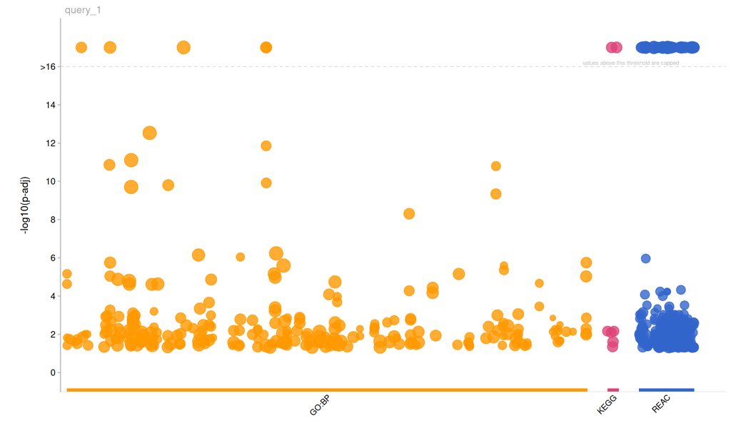

Functional enrichment - genes overexpressed in early tumors (Factor5 positive weights).

```r
gostplot(gost_early, interactive = FALSE, capped = TRUE)
```

```r
knitr::kable(
  head(gost_early$result[,
    c("term_name", "p_value", "term_size", "intersection_size")], 10),
  caption = "Top 10 enriched pathways - early tumor genes"
)
```

Top 10 enriched pathways - early tumor genes

| term_name | p_value | term_size | intersection_size |
| --- | --- | --- | --- |
| cytoplasmic translation | 0 | 165 | 64 |
| translation | 0 | 727 | 74 |
| protein metabolic process | 0 | 4721 | 92 |
| ribosome biogenesis | 0 | 323 | 32 |
| ribosomal small subunit biogenesis | 0 | 104 | 20 |
| gene expression | 0 | 9224 | 102 |
| ribosome assembly | 0 | 63 | 12 |
| macromolecule biosynthetic process | 0 | 9643 | 102 |
| rRNA processing | 0 | 225 | 17 |
| positive regulation of signal transduction by p53 class mediator | 0 | 28 | 9 |

**Cytoplasmic translation** (p = 10⁻¹⁰⁰) is the most significantly enriched pathway - a strong and homogeneous signal reflecting the coordinated ribosomal program of early-stage differentiated cells.

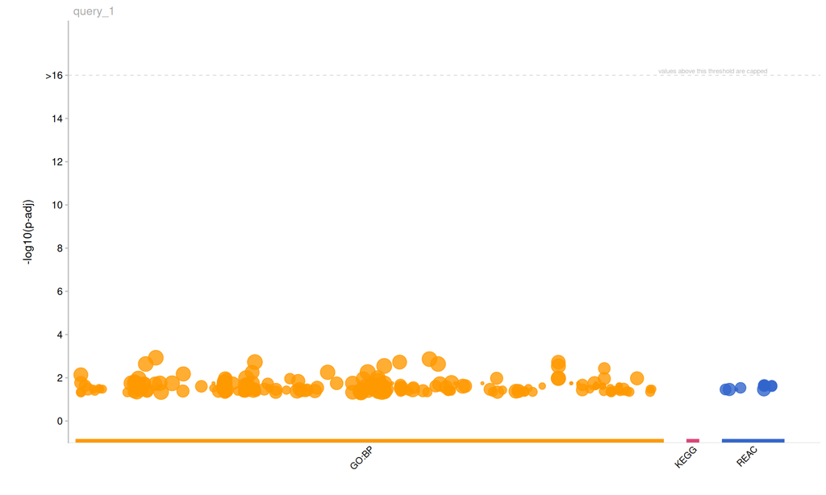

Functional enrichment - genes overexpressed in advanced tumors (Factor5 negative weights).

```r
gostplot(gost_advanced, interactive = FALSE, capped = TRUE)
```

```r
knitr::kable(
  head(gost_advanced$result[,
    c("term_name", "p_value", "term_size", "intersection_size")], 10),
  caption = "Top 10 enriched pathways - advanced tumor genes"
)
```

Top 10 enriched pathways - advanced tumor genes

| term_name | p_value | term_size | intersection_size |
| --- | --- | --- | --- |
| anatomical structure morphogenesis | 0.0011786 | 2713 | 11 |
| regulation of biological quality | 0.0013681 | 2947 | 11 |
| macromolecule localization | 0.0018777 | 3228 | 11 |
| cellular response to nitrogen compound | 0.0018777 | 645 | 6 |
| regulation of cellular localization | 0.0018777 | 1013 | 7 |
| protein localization | 0.0022993 | 2770 | 10 |
| cellular macromolecule localization | 0.0022993 | 2782 | 10 |
| cellular response to oxygen-containing compound | 0.0028456 | 1182 | 7 |
| cellular localization | 0.0028456 | 3661 | 11 |
| positive regulation of protein localization to cell periphery | 0.0037016 | 76 | 3 |

Advanced tumor genes are enriched in morphogenesis, macromolecule localization, and cellular remodeling pathways - consistent with the invasive and migratory behavior of late-stage colorectal cancer.

# 8. Conclusion

Factor5, identified by MOFA+ without any prior knowledge of tumor stage, captures a biologically coherent transition between two cellular states in colorectal cancer :

|  | Early tumors | Advanced tumors |
| --- | --- | --- |
| **RNA signature** | Ribosomal genes (RPL/RPS) | Motility genes (MYH9, MYH14) |
| **Methylation** | FZD10, XKR6 hypermethylated | NF1, HOXD10, TJP2 hypermethylated |
| **Pathways** | Cytoplasmic translation (p = 10⁻¹⁰⁰) | Morphogenesis, cell localization |
| **Biology** | Active, differentiated cells | Dedifferentiated, invasive cells |

This multiomics signature is consistent with known mechanisms of colorectal cancer progression and demonstrates the value of joint analysis across molecular layers to uncover biologically interpretable patterns.